# CS 422 Section 01

## 2.3 Problem : K-Means & PCA

##### Read file

```r
HtruData <- read.csv('HTRU_2-small.csv',header=T,sep=",")
HtruDataScaled <- scale(HtruData)
```

##### 2.3 A Perform PCA on the dataset

```r
HtruPCA<-prcomp(HtruDataScaled)
```

##### 2.3 A(i) How much cumulative variance is explained by the first two components?

```r
summary(HtruPCA)
```

```
Importance of components:
                          PC1    PC2     PC3     PC4     PC5     PC6     PC7
Standard deviation     2.1800 1.4746 0.90276 0.70713 0.56357 0.51104 0.38292
Proportion of Variance 0.5281 0.2416 0.09055 0.05556 0.03529 0.02902 0.01629
Cumulative Proportion  0.5281 0.7696 0.86021 0.91576 0.95105 0.98007 0.99636
                           PC8    PC9
Standard deviation     0.13188 0.1238
Proportion of Variance 0.00193 0.0017
Cumulative Proportion  0.99830 1.0000
```

> Variance explained by first two components is 0.7696

##### 2.3 A(ii) Plot the first two principal components. Use a different color to represent the observations in the two classes

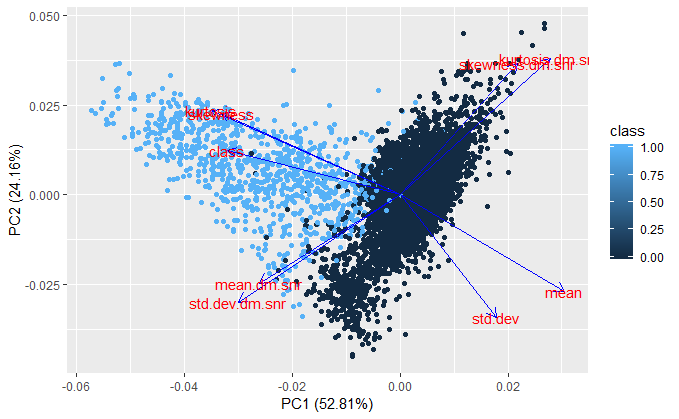

```r
autoplot(HtruPCA, data = HtruData, colour = "class", loadings = TRUE,loadings.colour = 'blue',loadings.label = TRUE)
```

##### 2.3 B Perform K-Means on above dataset

##### 2.3 B(i) Perform K-means clustering on the dataset with centers = 2, and nstart = 25

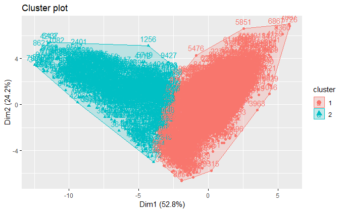

```r
HtrKMeans <- kmeans(HtruDataScaled, centers=2, nstart=25)
fviz_cluster(HtrKMeans, data=HtruData)
```

##### 2.3 B(ii)Provide observations on the shape of the clusters you got in (b)(i) to the plot of the first two principal components in (a)(ii). If the clusters are are similar, why? If they are not, why?

> Clusters are similar but not same as PCA considers only few attributes in above case 2 which explains highest standard deviation whereas k-means considers all the available attributes

##### 2.3 B(iii) What is the distribution of the observations in each cluster?

```r
sprintf("Distribution of cluster is ")
```

```
[1] "Distribution of cluster is "
```

```r
HtrKMeans$size
```

```
[1] 9183  817
```

##### 2.3 B(iV) What is the distribution of the classes in the HTRU2 dataset?

```r
class1 <- sum(HtruData$class)
sprintf(" Class 1 have %d Obs" , class1)
```

```
[1] " Class 1 have 959 Obs"
```

```r
sprintf(" Class 0 have %d Obs" , dim(HtruData)[1] - class1)
```

```
[1] " Class 0 have 9041 Obs"
```

##### 2.3 B(V) Based on the distribution of the classes in (b)(iii) and (b)(iv), which cluster do you think corresponds to the majority class and which cluster corresponds to the minority class?

> Based on distribution of classes in b(iii) and b(iV), Cluster 1 corresponds to majority class that is class 0.

##### 2.3 B(Vi) Let’s focus on the larger cluster. Get all of the observations that belong to this cluster. Then, state what is the distribution of the classes within this large cluster; i.e., how many observations in this large cluster belong to class 1 and how many belong to class 0?

```r
HtruDataC1 <- HtruData[HtrKMeans$cluster==1,]
num <- sum(HtruDataC1$class)
sprintf(" Number of obs belonging to class 1 in large cluster %d" , num)
```

```
[1] " Number of obs belonging to class 1 in large cluster 164"
```

```r
sprintf(" Number of obs belonging to class 0 in large cluster %d" , dim(HtruDataC1)[1] - num)
```

```
[1] " Number of obs belonging to class 0 in large cluster 9019"
```

##### 2.3 B(Vii)Based on the analysis above, which class (1 or 0) do you think the larger cluster represents?

> Based on above analysis larger cluster represents class 0

##### 2.3 B(Viii)How much variance is explained by the clustering?

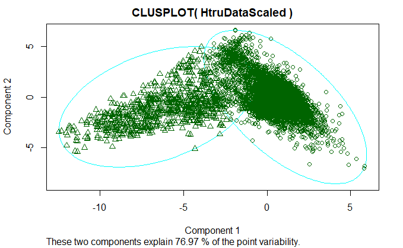

```r
clusplot(HtruDataScaled, HtrKMeans$cluster)
```

##### 2.3 B(iX)What is the average Silhouette width of both the clusters?

```r
SilOfHtr<- silhouette(HtrKMeans$cluster, dist(HtruData))
summary(SilOfHtr)
```

```
Silhouette of 10000 units in 2 clusters from silhouette.default(x = HtrKMeans$cluster, dist = dist(HtruData)) :
 Cluster sizes and average silhouette widths:
     9183       817
0.2814450 0.5442131
Individual silhouette widths:
   Min. 1st Qu.  Median    Mean 3rd Qu.    Max.
-0.6034  0.2124  0.3963  0.3029  0.4719  0.6784
```

> Average silhouette widths of both clusters is 0.2814450,0.5442131

##### 2.3 B(X)What is the per cluster Silhouette width? Based on this, which cluster is good?

```r
silhswdth <- silhouette(HtrKMeans$cluster,dist(HtruDataScaled))
a<-summary(silhswdth)
a$clus.avg.widths
```

```
        1         2
0.6599447 0.3714456
```

> Silhouette width tells us about how given object is related to its own cluster,For 1st cluster value is 0.6599447 and for second it is 0.3714456 As per given information cluster one has greater average silhouette width so it’s a better cluster

##### 2.3 C Perform K-means on the result of the PCA you ran in (a). More specifically, perform K-means on the first two principal component score vectors (i.e., pca$x[, 1:2]). Use k = 2.

```r
kout <- kmeans(HtruPCA$x[, 1:2], centers=2, nstart=25)
```

##### 2.3 C(i) Plot the clusters and comment on their shape with respect to the plots of a(ii) and b(i).

```r
fviz_cluster(kout, data=HtruData)
```

[output not shown]

##### 2.3 C(ii) What is the average Silhouette width of both the clusters?

```r
NewSil<- silhouette(kout$cluster, dist(HtruData))
summary(NewSil)
```

[output not shown]

##### 2.3 C(iii) What is the per cluster Silhouette width? Based on this, which cluster is good?

```r
silhswdth1 <- silhouette(kout$cluster,dist(HtruDataScaled))
a1<-summary(silhswdth1)
a1$clus.avg.widths
```

```
        1         2
0.6611024 0.3817566
```

> Silhouette width tells us about how given object is related to its own cluster,For first cluster value is 0.6611024 and for second it is 0.3817566 As per given information cluster one has greater average silhouette width so it’s a better cluster